# BDD100K · Tiền xử lý có giúp phát hiện xe?

Review trực quan · YOLO26n · S20 · một seed

# 1 Kết luận trong một phút

**Câu hỏi:** tăng sáng, tương phản hoặc chi tiết trước YOLO26n có giúp phát hiện xe, nhất là xe hai bánh, hay không?

**Important**

**Chưa có preprocessing đủ bằng chứng thay Raw.** Tăng resolution cho tín hiệu lớn hơn các filter đã thử. Adaptive đã được train S20/960 riêng, nhưng chưa cải thiện AP tổng và làm giảm AP motorcycle/bicycle.

Tất cả trained results là **một seed, development đã dùng chọn checkpoint**; không có kết quả final-test hay policy được xác nhận độc lập.

**Đường đọc:** dữ liệu → cách xử lý → ba phép so sánh → quyết định. Các tab chứa góc nhìn bổ sung; bấm ảnh để phóng to. AP dùng %, chênh lệch dùng **pp**: 20%→21% là +1 điểm phần trăm. Evidence snapshot: **`7527187`**.

# 2 Dữ liệu: cùng ảnh, cùng nhãn, khác xử lý

BDD100K/BDD2018 hiện có **69 863 official-train ảnh** và 10 000 official-val records. Các ảnh train/development là **1280×720**. Năm lớp theo thứ tự: **car, truck, bus, motorcycle, bicycle**; railway `train` đã bị loại, không loại ảnh âm theo. Annotation BDD/Scalabel→COCO→YOLO giữ tọa độ, kiểm tra round-trip trong **0.01 pixel**.

[figure not shown]

Figure 1: S20 là subset của training pool, không phải 20% toàn BDD100K. Car chiếm khoảng 93.3% GT development; trục số box bên phải dùng thang log.

- **S20:** 9 781 ảnh /5 915 nhóm, 73 ảnh âm; chứa toàn bộ S10 lịch sử (4 890 ảnh). **Development:** 13 975 ảnh /8 258 nhóm, 121 ảnh âm.
- Official train chia xấp xỉ **70/10/20**, seed2026, giữ nguyên nhóm và phân bố tự nhiên. Chọn S10/S20 chỉ theo train, không theo AP; không cân lớp lại.
- Nhóm suy từ filename-prefix, union với duplicate/dHash candidates. Đây là best-effort chống leakage, không chứng minh tách mọi video/near-duplicate.
- **9 730 final-test ảnh vẫn sealed**: không đọc pixel/header/hash/preview hay prediction. Con số này loại 96 exposure, 169 ảnh liên quan và 5 ảnh cùng nhóm official train khỏi 10 000 official-val.

# 3 Phương pháp và thiết lập chung

**Pipeline mọi arm:** original decode → feature/routing từ pixel → transform → **JPEG95 một lần** → YOLO26n. Raw cũng encode JPEG95; Skip phải Raw-identical. GT, ID, geometry và negatives không đổi. Filter chạy offline, không dùng weather, GT hay prediction để route; chi phí online phải tính riêng.

**Raw & Gamma**

**v0 Raw:** không enhancement.

**v1 Gamma-or-Skip:** brightness<0.12 → Gamma0.85; còn lại Skip. Với kênh 8-bit `x`: `floor(255 × (x/255)^0.85)`, cắt [0,255]. Đây là policy lịch sử mang tên **“Adaptive v2”**, không phải local-shadow v2. CLAHE/denoise/sharpen đã disable vì thiếu calibration support.

**Local-shadow**

**v2:** grayscale ở cạnh dài≤512 → Gaussian sigma16 lấy illumination `L` chuẩn hóa → gain `clip(sqrt(0.25/max(L,0.0625)),1,2)` → resize gain bilinear về gốc → nhân BGR rồi clip uint8.

Nâng sáng theo vị trí 1×–2×, không đổi GT. Rủi ro: noise/clipping tăng, không cứu được detail đã mất. Pilot âm và S20 training về sau là hai study riêng, không viết lại gate cũ.

**Gamma → Sharpen**

Pilot v3 cũ có **E:** brightness<0.18, contrast<0.20, black fraction<0.10, noise≤0.01; **D:** 50≤sharpness<150, noise≤0.01.

E-only áp Gamma0.85; D-only áp unsharp amount0.15/sigma1; cả hai áp **Gamma rồi Sharpen**; còn lại Skip. Unsharp là `1.15×ảnh −0.15×Gaussian(ảnh)`, clip8-bit. Không tìm reverse-order để cứu kết quả sau khi xem AP.

**Adaptive local contrast**

**v3 mới:** Apply khi contrast<0.20, 0.04<brightness<0.80, noise≤0.01, black fraction<0.30 và white fraction<0.10; còn lại Skip.

Grayscale `Y` → CLAHE(clip1.5, grid8×8) được `E`. Tính `p=clip(min(Y−8,247−Y)/32,0,1)` và `offset=round(clip(0.5×(E−Y),−12,12)×p)`. Cộng cùng offset vào BGR, clip từng kênh về [0,255]. Always-on control dùng cùng operator, không router.

Mỗi kênh đổi≤12; grayscale cực tối/sáng được bảo vệ. **Không bảo toàn màu tuyệt đối** nếu một kênh clip: (0,160,255) có thể thành (2,162,255).

**Feature & giới hạn**

Đo trên grayscale cạnh dài≤512: **brightness=mean/255**, **contrast=std/255**, **sharpness=variance Laplacian**, **noise=median(abs(gray−median3×3))/ (0.6745×255)**; black/white fraction là tỷ lệ gray≤3/≥252.

Global feature không mô tả riêng chiếc xe. Texture làm tăng sharpness; noise proxy có thể bằng0. “Dark” theo pixel không đồng nhất metadata night. Lịch sử còn dùng high-pass noise với đơn vị khác, không tráo threshold.

## 3.1 Recipe và cách đọc metrics

| Training được giữ cố định | Evaluation và selection |
| --- | --- |
| YOLO26n COCO init **độc lập** mỗi arm; seed2026 | Cùng development/GT; native matching/AP, không metric tự chế |
| **20 epoch, batch16, FP32**, AdamW, freeze11, nbs64 | FP32, batch32, conf0.001, max_det300, NMS-free |
| lr0=.001, lrf=.01, cosine, warmup3, weight decay=.0005 | AP50 tại IoU.50; **AP50:95** trung bình IoU.50:.95, macro đều năm lớp |
| Tắt HSV/geometry/flips/mosaic/mixup/cutmix và augmentation bổ sung | TP/FP/FN riêng tại **conf≥.25, matching IoU.50**, không phải native max-F1 point |

Full-resolution/post-hoc chọn best trên **Raw development actual640/pad0**, tensor384×640; matrix infer nominal640/960, pad.5, actual384×672/576×992. Selector AP không phải matrix AP. **Best Raw640 không bảo đảm tối ưu Adaptive960.** S20/640 cũ dùng padding selector lịch sử khác.

Dark nghĩa là **brightness<0.12 trên Raw pixel**, không phải metadata night. Raw-JPEG cache mới có 3 308 dark ảnh; S20/640 cũ đo từ original pixel có 3 307. Split group đã union duplicate; bootstrap dùng source_group gốc.

Bootstrap resample nguyên **source group có hoàn lại**, ghép cùng draw trước/sau, class target cố định; thiếu lớp thì invalid, không zero-impute/ redraw. CI chỉ có điều kiện trên model/development, **không chứa seed/ selection uncertainty hay multiplicity correction**. Năm nhóm là floor kỹ thuật, không bảo đảm thống kê.

# 4 Kết quả I · Preprocessing S20/640

**Raw 20.6124% → Gamma 20.6879% → local-shadow 20.4930% mAP50:95.** Giữ cùng 9 781 ảnh/20 epoch/640 và chọn trên Raw development, đánh giá mỗi model trên policy tương ứng. Selected epoch 9/10/9.

[figure not shown]

Figure 2: Trái: chênh lệch nhỏ, một seed, không có CI mới. Phải: đo CPU cùng 256 ảnh, 8 threads, 3 repeats; mean là bar, điểm là p95. Không gồm decode/JPEG/detector.

Gamma hơn Raw chỉ **+0.0755pp**. Local-shadow có mAP50 nhỉnh hơn nhưng thua primary AP50:95 và tốn CPU. Dark macro tăng nhẹ không đủ cứu: dark motorcycle AP **4.8689→2.8760→2.5007%**. Low-sharpness chỉ 122 ảnh, thiếu bicycle GT; không kết luận robustness lớp hiếm.

# 5 Kết quả II · Resolution có tín hiệu lớn hơn

Full S20, hai train arm chỉ khác resolution, cùng fixed-640 selector. **B−A** là inference resizing; **D−B** mới là phần training960 bổ sung khi giữ infer960. D−A thay cả hai yếu tố.

[figure not shown]

Figure 3: Cùng 13 975 development. CI95% theo source group: toàn population cho năm lớp; hàng cuối là riêng dark-bus. Dark-bus có 163GT/129groups, không phải cùng estimand với bus tổng.

- **Resizing B−A +1.7856pp; thêm training D−B +2.1705pp**, CI **[+1.7727,+2.6196]pp**, 1 000 valid/0 missing-class draws.
- **Dark-bus vẫn inconclusive:** AP+0.170pp nhưng CI[−2.952,+3.415]pp, TP 40→31/FN 123→132 ở conf.25. Positive primary CI không xóa coverage này.
- Tổng TP/FP/FN B→D: **85 335/28 800/67 439 →83 620/20 743/69 154**: ít FP hơn nhưng cũng ít TP hơn, dù AP tăng.

**Vì sao nghiên cứu đi theo hướng resolution?**

Trên 1 027 ảnh exploration đã consumed, frozen pretrained infer640→960 tăng **+2.3727pp**, CI[+1.3602,+3.9616], nhưng motorcycle/bicycle TP vẫn 1/14. Short diagnostic 2 048 train ảnh/5 epoch sau đó có training gain+0.9134pp, CI[−0.0819,+1.7789] cắt0 và dark-bus−7.7661pp. Attempt đầu lỗi API; repeat được khai báo riêng, không là replicate độc lập. Full-S20 thay cả quần thể/budget/selector, nên không gán khác biệt pilot→full cho riêng số epoch.

# 6 Kết quả III · Adaptive: pilot rồi training riêng

## 6.1 Hai pilot đều không qua gate

[figure not shown]

Figure 4: Hai study khác population/model: Gamma/Sharpen dùng 1 027 ảnh, pretrained640; local-contrast dùng 1 479 ảnh, trained Raw960. Chỉ đọc gain ghép cặp trong mỗi study, không xếp hạng absolute AP giữa chúng. CI có điều kiện, không independent confirmation.

Local-contrast mới tăng **+0.1475pp**, dưới gate+0.2; CI cắt0; two-wheeler mean+0.2759 dưới gate+0.5; dark-bus−1.6165pp vượt tolerance1pp. Cost **5.811/11.913ms mean/p95** và route-control đạt, nhưng **bốn gate fail vẫn fail**. Apply 584/1 479 ảnh; phần lớn motorcycle/bicycle GT bị Skip vì contrast không đạt ngưỡng. Không retune trên pool exploration nay đã consumed.

## 6.2 Train consistent input domain có cứu được không?

Một yêu cầu riêng sau pilot âm cho phép **post-hoc train Adaptive 20 epoch/960 từ COCO độc lập**, không biến pilot thành passed. Train route **3 916 Apply/ 5 865 Skip**; development **5 653/8 322**. Selector vẫn Raw actual640/pad0, chọn Adaptive epoch12, Raw epoch10. Không reselect trên Adaptive960.

[figure not shown]

Figure 5: Trái dùng cùng scale màu 18–30% với matrix resolution để không phóng đại các chênh lệch rất nhỏ. Phải là D−B: thay training arm nhưng giữ Adaptive input. Một seed, không có CI mới.

**D−B −0.0123pp; D−A −0.0429pp.** Macro gần hòa không chứng minh Adaptive luôn kém, nhưng motorcycle−1.4261pp/bicycle−0.7997pp là lo ngại thực tế hơn. D−A đổi cả model lẫn input; không coi đó là training effect riêng.

**Recall / precision & cohort**

[figure not shown]

Figure 6: Trái: chỉ hai operating points tại conf≥.25/IoU.50, không phải đường PR hoặc AP. Phải: AP của image cohort giữ mọi GT; small-two-wheeler không phải AP-small.

A→D: **TP 83 620→88 649; FP 20 743→27 158; FN 69 154→64 125**. Tổng bị car chi phối: motorcycle TP 112→101; bicycle TP 332→371 nhưng FP 145→235. Dark motorcycle TP 6→3. Small-two-wheeler macro tăng nhưng motorcycle AP 6.6441→5.6499%; không suy ra xe nhỏ được cải thiện chung.

**Apply / Skip**

[figure not shown]

Figure 7: Saved-match aggregation, không inference mới. D−B ở Apply macro+0.1369pp và Skip−0.0324pp, nhưng hai lớp ưu tiên đều giảm. Nhóm có thể span hai route; không cộng AP theo trọng số ảnh.

Skip giữ A=B, C=D chính xác với từng checkpoint vì input bytes giống nhau. Nhưng model trained mới được dùng cho mọi ảnh, nên training-arm difference vẫn có thể xuất hiện ở Skip. Đây là consistency check, không causal proof.

# 7 Chi phí và hội tụ: gain phải trả bằng gì?

[figure not shown]

Figure 8: Selector là Raw actual640/pad0 cho cả ba arm; không phải AP inference960. Wall gồm epoch selection/terminal validation; cost một host, không benchmark thứ tự ngẫu nhiên.

- Raw960 so Raw640: **1.388×training wall**, **2.23×allocated VRAM**; native inference khoảng**2.48 vs1.03ms/ảnh**. Same infer960, Raw/Adaptive checkpoint đều khoảng2.38ms trong post-hoc matrix.
- Native inference đọc ảnh **đã export**, không chứa CPU preprocessing, decode/JPEG/I/O đầy đủ. Batchp95 không phải per-imagep95 hay deployment SLA.
- Adaptive train 86.77min so Raw 91.18min không chứng minh speedup; cache/order/ nhiệt khác nhau. Epoch20 train loss giảm không bảo đảm selector AP tốt lên.
- Full-resolution CPU bootstrap continuation mất 65.07min riêng; đã ngắt rồi tiếp tục từ matches, không thêm GPU inference. Không gọi train wall là end-to-end nghiên cứu hay GPU busy time.

# 8 Những hướng đã thử: giữ bài học, không lặp toàn nhật ký

**Denoise & ordered pairs**

Round2 dùng 20 treatments, 10 scenarios clean/underexposure/noise/motion, objective cân đều family; không phải prevalence triển khai. NLM5 exploration **18.8825%**, hơn Gamma-or-Skip **+0.6588pp**; confirmation 260 ảnh lại **−0.5516pp**, CI[−1.4674,+0.0919], CPU~165.7ms/ảnh. **Reject**, không chọn runner-up sau confirmation.

Sharpen→Bilateral hơn chiều ngược trong điểm estimate; Gamma↔︎CLAHE đều dưới Skip. Hai filter không tự tốt hơn một. Synthetic corruptions chỉ xấp xỉ, không là camera/ISP/fog model đã hiệu chuẩn.

**Routing không transfer**

Route theo contrast/noise trên exploration cũ có lợi nhưng chuyển cohort mới mất hiệu ứng. Sentinel so Gamma-or-Skip trên hai slice 256 ảnh: slice cũ **+0.59575pp**; slice mới **−0.01621pp**, CI[−0.24858,+0.32628]. Hai slice dùng cùng định nghĩa sentinel, không pool để che failure-to-transfer. Chi phí đạt gate nhưng benefit không reproduce; dừng sentinel thay vì tiếp tục chỉnh threshold trên ảnh đã xem. Không suy ra mọi router đều vô ích.

**S10 & lịch sử xa hơn**

S10 train 20 epoch: Raw/Gamma policy-matched AP **19.0756/19.3631%** trên development. Giữ input cố định, training contrast+0.2492/+0.2771pp với CI có điều kiện dương, nhưng một seed, không xác nhận độc lập. Raw từng resume sau epoch12; best epoch6 trước interruption. Verified reuse sau đó không là replicate mới.

Synthetic screen cũ shortlist CLAHE trên veil medium, supported-five-class gain+1.4356pp; không chứng minh natural fog hay router. Railway chỉ một group làm bootstrap sáu lớp cũ đổi denominator; dùng corrected fixed-target analysis, không dùng CI v1. Snapshot YOLO11 epoch1 không phải completed baseline và không so chung với taxonomy/split hiện tại.

# 9 Ảnh chẩn đoán và ranh giới kết luận

**Giữ Raw làm đối chứng; chưa promote filter nào.** Raw960 là reference phát triển có tín hiệu AP, không là model được final-test chứng nhận. Nếu ưu tiên recall, cần đặt ngân sách FP và đánh giá riêng từng lớp; không coi macro gần hòa là không có regression quan trọng.

**Xem batch GT/prediction thực tế — cùng source IDs, không chọn ảnh để tối đa gain**

**GT**

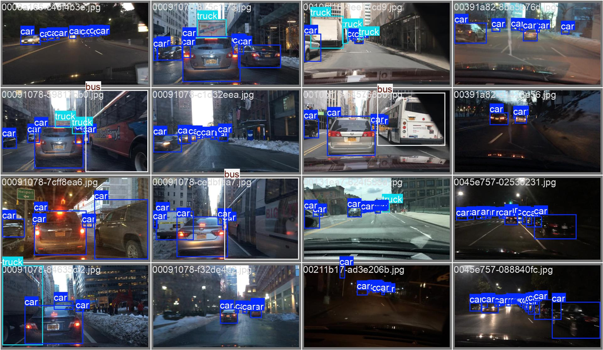

GT batch0, Raw development.

**Raw prediction**

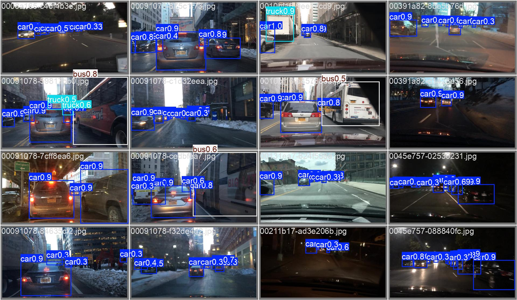

Raw960 trên Raw input của cùng batch.

**Adaptive prediction**

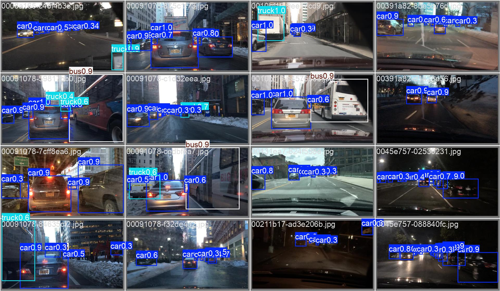

Adaptive960 trên Adaptive input của cùng batch.

Counts dùng native matching; không suy ra AP từ một frame. Saved matches không có matched GT index/FP geometry để kết luận nguyên nhân từng miss.

**Xem PR/confusion native**

**PR**

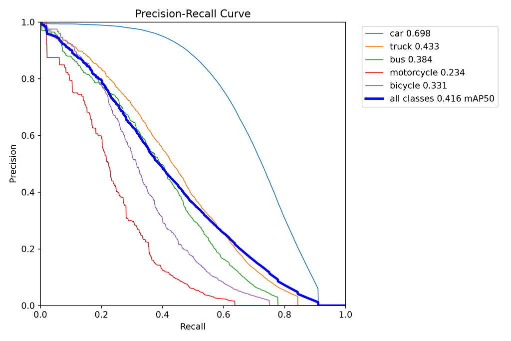

Raw960/Raw; legend là AP50.

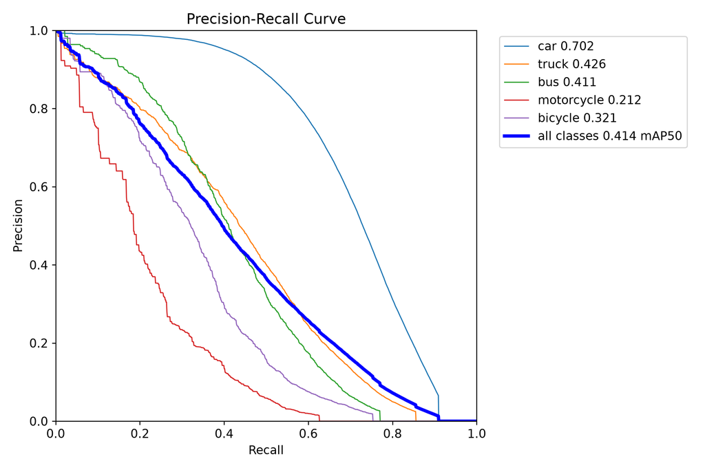

Adaptive960/Adaptive; không phải AP50:95.

**Confusion**

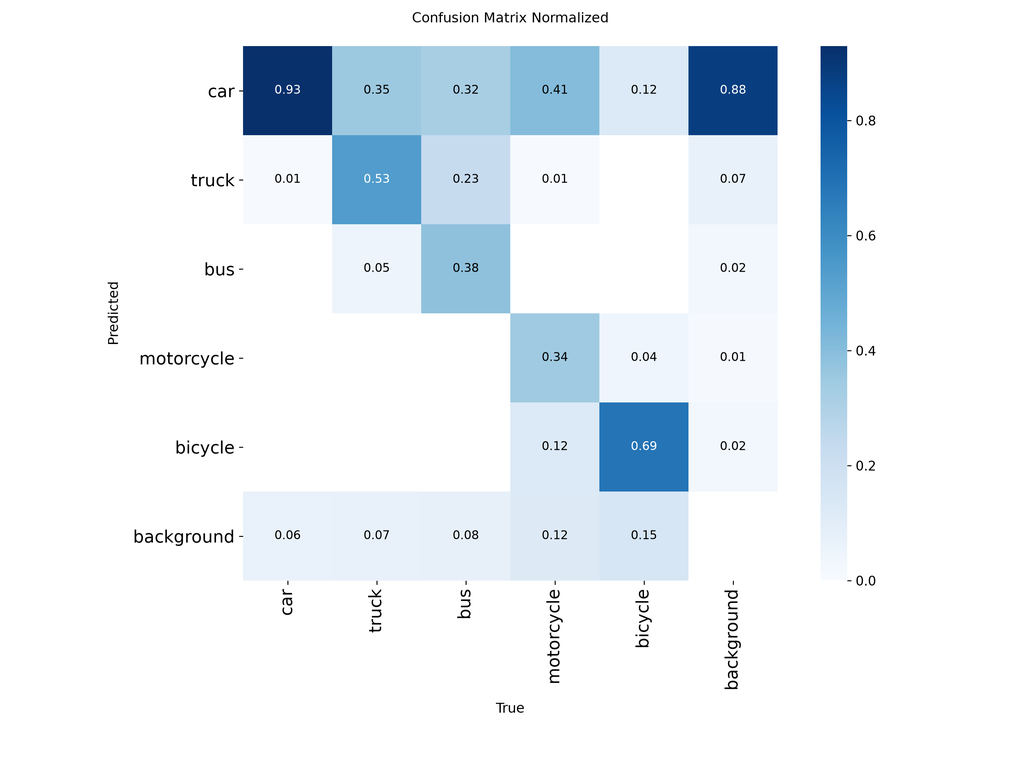

Native normalized confusion, Raw960/Raw.

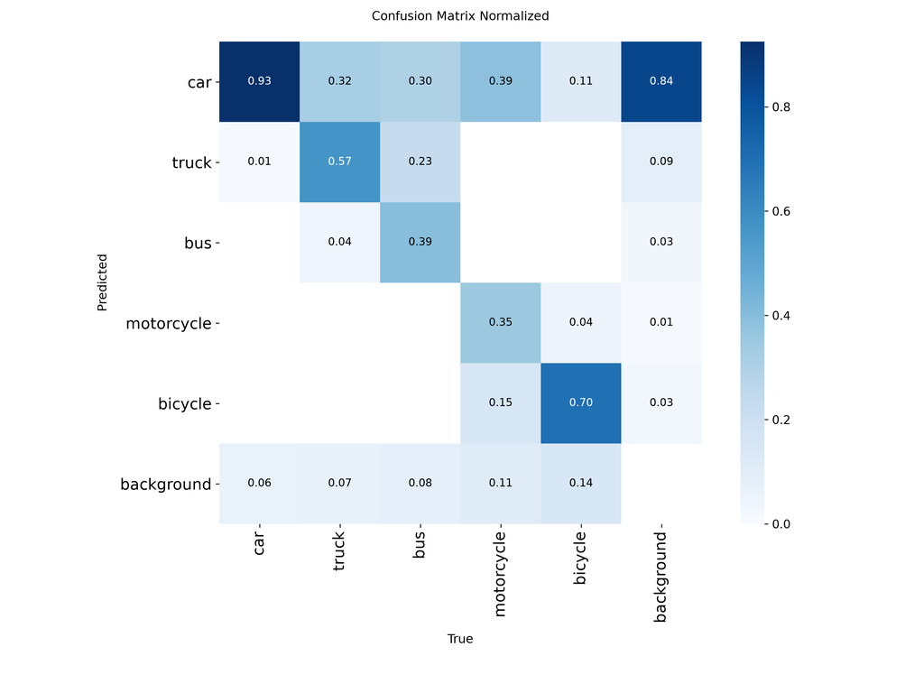

Native normalized confusion, Adaptive960/Adaptive.

Confusion chart dùng cấu hình matching native riêng, không thay bảng counts tại conf.25/IoU.50.

**Không suy diễn vượt evidence:** single-seed/reused-development không chứng minh generalization; image-cohort AP không là AP-small; contrast/noise proxy không là object-level cause. Pool 1 479 fresh-exploration hiện đã consumed, không tái gắn nhãn confirmation. Một confirmation Denoise lịch sử đã chạy; các reservation chưa dùng và final vẫn sealed.

Một study mới phải có protocol, dữ liệu đánh giá hợp lệ và operating point được phê duyệt trước; không tự tuning lại hoặc mở final để cứu kết quả.

**Nguồn số liệu, tái tạo biểu đồ và đọc offline**

Các plot mới được tính trực tiếp khi render từ **evidence đã commit**: S20 `issue45-s20`; resolution `issue47-s20-resolution-20e`; pilots `issue47`/`issue47-v3-960`; training/matrix `issue47-posthoc-adaptive-960`; routes `issue47-posthoc-routes`. Manifest SHA256 được kiểm tra trước vẽ. History đọc CSV 20 epoch; split đọc checksum-bound table; không mở dataset, checkpoint, runs, sealed pixels hoặc chạy bootstrap/inference.

Ảnh chẩn đoán giữ nguyên các bản copy đã tracking ở `docs/images/`: PR/confusion và batch0 GT/prediction từ các evaluation `eval_raw_raw` / `eval_adaptive_adaptive` trong run post-hoc. Plot mới nhúng thẳng vào HTML. Evidence khoa học và các ảnh native khác vẫn được giữ nguyên.

Môi trường đo: Ultralytics8.4.198, Torch2.15/CUDA13.2, NumPy2.4.6, OpenCV4.14.0.94, RTX5060Ti16GiB. Render chỉ cần project environment có Matplotlib/Pandas/PyYAML và Jupyter (study extra đã có), không cần GPU. Từ repository root:

```bash
QUARTO_PYTHON="$PWD/.venv/bin/python" quarto render docs/report.qmd --to html
```

`report.qmd` là source; `report.html` nhúng plot/ảnh/resources, mở offline không cần Python. Sau sửa source phải render lại HTML. Source plot được ẩn trong bản đọc; người đọc không cần mở code để hiểu phương pháp/kết luận.